# Sequential Search

merupakan teknik pencarian data dengan cara membandingkan data yang dicari dengan seluruh data yang terdapat pada kumpulan data secara satu persatu, mulai dari data pertama sampai dengan data terakhir.

## Unordered List Sequential Search

Pada unordered list sequential search, data berada pada keadaan acak, tidak terurut, sehingga pencarian harus dilakukan mulai dari indeks awal sampai indeks terakhir dari data, atau pencarian berhenti ketika data sudah ditemukan

```python
def seqSearch(listData, data):
    ind = 0
    found = False

    while ind < len(listData) and not found:
        if listData[ind] == data:
            found = True
        else:
            ind = ind + 1

    return found
```

```python
a=[12,5,9,8,1,10,26]
print(seqSearch(a,1))
print(seqSearch(a, 99))
```

```
True
False
```

```python
def unorderedSequential(listdata, cari):
  ind=0
  found=False
  while ind<len(listdata) and not found:
    if cari==listdata[ind]:
      found=True
    else:
      ind=ind+1
  return found

lsdata= [3,6,2,7,4,12,40]
unorderedSequential(lsdata, 11)
```

```
False
```

## ordered list sequential search

data sudah dalam keadaan terurut, hal ini tentunya dapat mengurangi waktu komputasi pencarian. Ilustrasi algoritma pencarian ini, dapat dilihat pada Gambar 2 berikut:

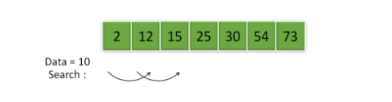

```python
def orderedSeqSearch(listData, data):
    ind = 0
    found = False
    stop = False
    position = []

    while ind < len(listData) and not found and not stop:
        if listData[ind] == data:
            found = True
            position.append(ind)
        else:
            if listData[ind] > data:
                stop = True
            else:
                ind = ind + 1

    if found:
        return ind
    else:
        return "Data tidak ada"
```

```python
angka = [10, 20, 30, 40, 50]

print(orderedSeqSearch(angka, 30))
print(orderedSeqSearch(angka, 25))
```

```
2
Data tidak ada
```

```python
def orderedSequential(listdata, cari):
  ind=0
  found=False
  stop=False
  while ind<len(listdata) and not found and not stop:
    if cari==listdata[ind]:
      found=True
    else:
      if listdata[ind]>cari:
        stop=True
      else:
        ind=ind+1
  return found

lsdata= [3,6,7,9,12,15,70]
unorderedSequential(lsdata, 9)
```

```
True
```

## binary search

Pencarian dengan algoritma sequential search akan menemukan data dengan cepat jika data yang dicari terletak di indeks pertama dari suatu list data. Akan tetapi jika data yang dicari berada di posisi terakhir dari suatu list atau posisi lain, maka algoritma sequential search ini akan membutuhkan waktu yang lebih lama, karena algoritma ini akan mencari satu persatu, dimulai dari indeks pertama sampai dengan indeks terakhir. Pada algoritma binary search pencarian tidak dilakukan satu persatu, melainkan memanfaatkan kelebihan pencarian di data yang sudah terurut. Pada binary search, pencarian dilakukan pertama kali di indeks list yang berada ditengah. Jika data yang dicari sama dengan data pada indeks tersebut, maka pencarian berakhir. Akan tetapi jika data yang dicari lebih besar dari data yang berada di indeks tengah tersebuh, maka dilakukan pencarian lagi. Hanya saja pencarian tidak dilakukan pada seluruh data, hanya data yang berada indeks-indeks setelah indeks tengah tadi, karena data sebelum indeks tengah, pasti lebih kecil nilainya, sehingga tidak perlu dilakukan pencarian lagi. Proses ini dilakukan secara terus menerus sampai data ketemu atau tidak ada lagi data yang dapat dicari di dalam list. Oleh karena itu, binary search tidak perlu mencari di semua data pada list, sehingga waktu komputasi yang dibutuhkan lebih cepat dibandingkan dengan pencarian sequential search. Ilustrasi pencarian binary search ini dapat dilihat pada Gambar berikut.

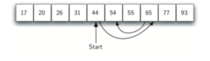

```python
def binarySearch(listData, data):
    first = 0
    last = len(listData) - 1
    found = False

    while first <= last and not found:
        midpoint = (first + last) // 2

        if listData[midpoint] == data:
            found = True
        else:
            if data < listData[midpoint]:
                last = midpoint - 1
            else:
                first = midpoint + 1

    return found

a=[4,6,10,34,56,78,99]
print(binarySearch(a,34))
```

```
True
```

```python
def binSearch(lsdata, cari):
  awal=0
  akhir=len(lsdata)-1
  found=False
  while awal<=akhir and not found:
    tengah=(awal+akhir)//2
    if lsdata[tengah]==cari:
      found=True
    else:
      if cari<=lsdata[tengah]:
        akhir=tengah-1
      else:
        awal=tengah+1
  return found

lsdata= [3,6,7,9,12,15,70]
print(binSearch(lsdata,9))
```

[output not shown]

```python
def cekTerurut(listdata):
  for i in range(len(listdata)-1):
    if listdata[i] > listdata[i+1]:
      return False
  return True

def sequentialSearch(listdata, cari):
  ind = 0
  found = False
  iterasi = 0
  while ind < len(listdata) and not found:
    iterasi += 1
    if cari == listdata[ind]:
      found = True
    else:
      ind = ind + 1
  if found:
    return ind, iterasi
  else:
    return -1, iterasi


def binarySearch(listdata, cari):
  awal = 0
  akhir = len(listdata)-1
  found = False
  iterasi = 0
  while awal <= akhir and not found:
    iterasi += 1
    tengah = (awal + akhir) // 2
    if listdata[tengah] == cari:
      found = True
    else:
      if cari < listdata[tengah]:
        akhir = tengah - 1
      else:
        awal = tengah + 1
  if found:
    return tengah, iterasi
  else:
    return -1, iterasi

data = [3,2,1]
key = 10
if cekTerurut(data):
  print("Status Data : Terurut")
  print("Algoritma yang digunakan : Binary Search")
  hasil, iterasi = binarySearch(data, key)
else:
  print("Status Data : Tidak Terurut")
  print("Algoritma yang digunakan : Sequential Search")
  hasil, iterasi = sequentialSearch(data, key)

if hasil != -1:
  print("Data ditemukan pada index ke-", hasil)
else:
  print("Data tidak ditemukan")

print("Jumlah iterasi :", iterasi)
```

```
Status Data : Tidak Terurut
Algoritma yang digunakan : Sequential Search
Data tidak ditemukan
Jumlah iterasi : 3
```

```python
def linearSearchTerdekat(listdata, cari):
  ind = 0
  found = False
  while ind < len(listdata) and not found:
    if cari == listdata[ind]:
      found = True
    else:
      ind += 1
  if found:
    print("Data ditemukan :", cari)
  else:
    selisihMin = abs(cari - listdata[0])
    terdekat = [listdata[0]]
    for i in range(1, len(listdata)):
      selisih = abs(cari - listdata[i])
      if selisih < selisihMin:
        selisihMin = selisih
        terdekat = [listdata[i]]

      elif selisih == selisihMin:
        terdekat.append(listdata[i])
    print("Data tidak ditemukan")
    print("Nilai terdekat :", end=" ")
    for i in range(len(terdekat)):
      if i == len(terdekat)-1:
        print(terdekat[i])
      else:
        print(terdekat[i], "dan", end=" ")

data = [10, 20, 30, 40, 50]

print("KEY = 33")
linearSearchTerdekat(data, 33)

print("\nKEY = 35")
linearSearchTerdekat(data, 35)
```

```
KEY = 33
Data tidak ditemukan
Nilai terdekat : 30

KEY = 35
Data tidak ditemukan
Nilai terdekat : 30 dan 40
```

```python
def urutkanData(listdata):
  data = listdata[:]
  n = len(data)
  for i in range(n-1):
    for j in range(n-1-i):
      if data[j] > data[j+1]:
        temp = data[j]
        data[j] = data[j+1]
        data[j+1] = temp
  return data

def linearRangeSearch(listdata, lower, upper):
  hasil = []
  iterasi = 0
  for i in range(len(listdata)):
    iterasi += 1
    if lower <= listdata[i] <= upper:
      hasil.append(listdata[i])
  return hasil, iterasi

def binaryRangeSearch(listdata, lower, upper):
  dataUrut = urutkanData(listdata)
  awal = 0
  akhir = len(dataUrut)-1
  hasil = []
  iterasi = 0
  while awal <= akhir:
    iterasi += 1
    tengah = (awal + akhir) // 2
    if dataUrut[tengah] < lower:
      awal = tengah + 1
    elif dataUrut[tengah] > upper:
      akhir = tengah - 1
    else:
      kiri = tengah
      while kiri >= 0:
        iterasi += 1
        if dataUrut[kiri] >= lower:
          kiri -= 1
        else:
          break

      kanan = tengah
      while kanan < len(dataUrut):
        iterasi += 1
        if dataUrut[kanan] <= upper:
          kanan += 1
        else:
          break

      hasil = dataUrut[kiri+1:kanan]
      break

  return dataUrut, hasil, iterasi

data = [5, 1, 8, 12, 3, 20, 15]
lower = 5
upper = 15
hasilLinear, iterasiLinear = linearRangeSearch(data, lower, upper)

print("HASIL LINEAR SEARCH (Unordered)")
print("Data dalam range :", hasilLinear)
print("Jumlah iterasi :", iterasiLinear)

print()
dataUrut, hasilBinary, iterasiBinary = binaryRangeSearch(data, lower, upper)
print("HASIL BINARY SEARCH")
print("Data terurut :", dataUrut)
print("Data dalam range :", hasilBinary)
print("Jumlah iterasi :", iterasiBinary)
```

```
HASIL LINEAR SEARCH (Unordered)
Data dalam range : [5, 8, 12, 15]
Jumlah iterasi : 7

HASIL BINARY SEARCH
Data terurut : [1, 3, 5, 8, 12, 15, 20]
Data dalam range : [5, 8, 12, 15]
Jumlah iterasi : 8
```

```python
data =[12, 5, 9, 8, 1, 10, 26, 5, 9, 5]
a=5

index=[]
iterasi=0

for i in range(len(data)):
  iterasi += 1
  if data[i] == a:
    index.append(i)

if len(index) > 0:
    print("Index:", index)
    print("Jumlah:", len(index))
    print("First:", index[0])
    print("Last:", index[-1])
else:
    print("Data tidak ditemukan")

print("Jumlah iterasi:", iterasi)
```

```
Index: [1, 7, 9]
Jumlah: 3
First: 1
Last: 9
Jumlah iterasi: 10
```

```python
def binarysearch(listdata, data, first, last):
  if first>last:
    print("data tidak di temukan")
  middle=(first+last)//2
  print(f"check index ke-{middle}")
  if listdata[middle]==data:
    print(f"data ditemukan pada index {middle}")
  elif data>listdata[middle]:
    binarysearch(listdata, data, middle+1, last)
  elif data<listdata[middle]:
    binarysearch(listdata,data, first,middle-1)

lsdata= [3,6,7,9,12,15,70]
binarysearch(lsdata,6,0,len(lsdata)-1)
```

```
check index ke-3
check index ke-1
data ditemukan pada index 1
```